# Bellabeat Case Study – Marketing Analysis

Everton

# 1 Ask

**Business task**  
- Bellabeat needs an analysis of consumer usage data from non-Bellabeat smart devices.  
- Goal: identify usage patterns and apply insights to one Bellabeat product (App, Leaf, Time, Spring, Membership).  
- Findings will support marketing strategies and future expansion.

**Stakeholders**  
- Urška Sršen (Cofounder & Chief Creative Officer)  
- Sando Mur (Cofounder & Executive Team Member)  
- Bellabeat Marketing Analytics Team

**Key questions**  
- What problem is Bellabeat trying to solve?  
- Expand business using data-driven marketing insights from customer usage of non-Bellabeat devices.

- How can insights drive business decisions?
  - Guide marketing strategies and identify opportunities for growth.

# 2 Prepare

```r
activity_raw <- read_csv("data_raw/dailyActivity_merged.csv")
sleep_raw    <- read_csv("data_raw/sleepDay_merged.csv")
steps_hour   <- read_csv("data_raw/hourlySteps_merged.csv")

glimpse(activity_raw)
```

```
## Rows: 457
## Columns: 15
## $ Id                       <dbl> 1503960366, 1503960366, 1503960366, 150396036…
## $ ActivityDate             <chr> "3/25/2016", "3/26/2016", "3/27/2016", "3/28/…
## $ TotalSteps               <dbl> 11004, 17609, 12736, 13231, 12041, 10970, 122…
## $ TotalDistance            <dbl> 7.11, 11.55, 8.53, 8.93, 7.85, 7.16, 7.86, 7.…
## $ TrackerDistance          <dbl> 7.11, 11.55, 8.53, 8.93, 7.85, 7.16, 7.86, 7.…
## $ LoggedActivitiesDistance <dbl> 0, 0, 0, 0, 0, 0, 0, 0, 0, 0, 0, 0, 0, 0, 0, …
## $ VeryActiveDistance       <dbl> 2.57, 6.92, 4.66, 3.19, 2.16, 2.36, 2.29, 3.3…
## $ ModeratelyActiveDistance <dbl> 0.46, 0.73, 0.16, 0.79, 1.09, 0.51, 0.49, 0.8…
## $ LightActiveDistance      <dbl> 4.07, 3.91, 3.71, 4.95, 4.61, 4.29, 5.04, 3.6…
## $ SedentaryActiveDistance  <dbl> 0.00, 0.00, 0.00, 0.00, 0.00, 0.00, 0.00, 0.0…
## $ VeryActiveMinutes        <dbl> 33, 89, 56, 39, 28, 30, 33, 47, 40, 15, 43, 3…
## $ FairlyActiveMinutes      <dbl> 12, 17, 5, 20, 28, 13, 12, 21, 11, 30, 18, 18…
## $ LightlyActiveMinutes     <dbl> 205, 274, 268, 224, 243, 223, 239, 200, 244, …
## $ SedentaryMinutes         <dbl> 804, 588, 605, 1080, 763, 1174, 820, 866, 636…
## $ Calories                 <dbl> 1819, 2154, 1944, 1932, 1886, 1820, 1889, 186…
```

```r
glimpse(sleep_raw)
```

```
## Rows: 413
## Columns: 5
## $ Id                 <dbl> 1503960366, 1503960366, 1503960366, 1503960366, 150…
## $ SleepDay           <chr> "4/12/2016 12:00:00 AM", "4/13/2016 12:00:00 AM", "…
## $ TotalSleepRecords  <dbl> 1, 2, 1, 2, 1, 1, 1, 1, 1, 1, 1, 1, 1, 1, 1, 1, 1, …
## $ TotalMinutesAsleep <dbl> 327, 384, 412, 340, 700, 304, 360, 325, 361, 430, 2…
## $ TotalTimeInBed     <dbl> 346, 407, 442, 367, 712, 320, 377, 364, 384, 449, 3…
```

```r
glimpse(steps_hour)
```

```
## Rows: 24,084
## Columns: 3
## $ Id           <dbl> 1503960366, 1503960366, 1503960366, 1503960366, 150396036…
## $ ActivityHour <chr> "3/12/2016 12:00:00 AM", "3/12/2016 1:00:00 AM", "3/12/20…
## $ StepTotal    <dbl> 0, 0, 0, 0, 0, 0, 0, 0, 0, 8, 551, 1764, 1259, 253, 4470,…
```

```r
activity_raw %>% skim()
```

Data summary

| Name | Piped data |
| --- | --- |
| Number of rows | 457 |
| Number of columns | 15 |
| _______________________ |  |
| Column type frequency: |  |
| character | 1 |
| numeric | 14 |
| ________________________ |  |
| Group variables | None |

**Variable type: character**

| skim_variable | n_missing | complete_rate | min | max | empty | n_unique | whitespace |
| --- | --- | --- | --- | --- | --- | --- | --- |
| ActivityDate | 0 | 1 | 8 | 9 | 0 | 32 | 0 |

**Variable type: numeric**

| skim_variable | n_missing | complete_rate | mean | sd | p0 | p25 | p50 | p75 | p100 | hist |
| --- | --- | --- | --- | --- | --- | --- | --- | --- | --- | --- |
| Id | 0 | 1 | 4.628595e+09 | 2.293781e+09 | 1503960366 | 2.347168e+09 | 4.057193e+09 | 6.391747e+09 | 8.877689e+09 | ▇▇▃▅▃ |
| TotalSteps | 0 | 1 | 6.546560e+03 | 5.398490e+03 | 0 | 1.988000e+03 | 5.986000e+03 | 1.019800e+04 | 2.849700e+04 | ▇▆▂▁▁ |
| TotalDistance | 0 | 1 | 4.660000e+00 | 4.080000e+00 | 0 | 1.410000e+00 | 4.090000e+00 | 7.160000e+00 | 2.753000e+01 | ▇▅▁▁▁ |
| TrackerDistance | 0 | 1 | 4.610000e+00 | 4.070000e+00 | 0 | 1.280000e+00 | 4.090000e+00 | 7.110000e+00 | 2.753000e+01 | ▇▅▁▁▁ |
| LoggedActivitiesDistance | 0 | 1 | 1.800000e-01 | 8.500000e-01 | 0 | 0.000000e+00 | 0.000000e+00 | 0.000000e+00 | 6.730000e+00 | ▇▁▁▁▁ |
| VeryActiveDistance | 0 | 1 | 1.180000e+00 | 2.490000e+00 | 0 | 0.000000e+00 | 0.000000e+00 | 1.310000e+00 | 2.192000e+01 | ▇▁▁▁▁ |
| ModeratelyActiveDistance | 0 | 1 | 4.800000e-01 | 8.300000e-01 | 0 | 0.000000e+00 | 2.000000e-02 | 6.700000e-01 | 6.400000e+00 | ▇▁▁▁▁ |
| LightActiveDistance | 0 | 1 | 2.890000e+00 | 2.240000e+00 | 0 | 8.700000e-01 | 2.930000e+00 | 4.460000e+00 | 1.251000e+01 | ▇▆▂▁▁ |
| SedentaryActiveDistance | 0 | 1 | 0.000000e+00 | 1.000000e-02 | 0 | 0.000000e+00 | 0.000000e+00 | 0.000000e+00 | 1.000000e-01 | ▇▁▁▁▁ |
| VeryActiveMinutes | 0 | 1 | 1.662000e+01 | 2.892000e+01 | 0 | 0.000000e+00 | 0.000000e+00 | 2.500000e+01 | 2.020000e+02 | ▇▁▁▁▁ |
| FairlyActiveMinutes | 0 | 1 | 1.307000e+01 | 3.621000e+01 | 0 | 0.000000e+00 | 1.000000e+00 | 1.600000e+01 | 6.600000e+02 | ▇▁▁▁▁ |
| LightlyActiveMinutes | 0 | 1 | 1.700700e+02 | 1.222100e+02 | 0 | 6.400000e+01 | 1.810000e+02 | 2.570000e+02 | 7.200000e+02 | ▇▇▂▁▁ |
| SedentaryMinutes | 0 | 1 | 9.952800e+02 | 3.370200e+02 | 32 | 7.280000e+02 | 1.057000e+03 | 1.285000e+03 | 1.440000e+03 | ▁▂▆▅▇ |
| Calories | 0 | 1 | 2.189450e+03 | 8.154800e+02 | 0 | 1.776000e+03 | 2.062000e+03 | 2.667000e+03 | 4.562000e+03 | ▁▅▇▃▁ |

```r
sleep_raw %>% skim()
```

Data summary

| Name | Piped data |
| --- | --- |
| Number of rows | 413 |
| Number of columns | 5 |
| _______________________ |  |
| Column type frequency: |  |
| character | 1 |
| numeric | 4 |
| ________________________ |  |
| Group variables | None |

**Variable type: character**

| skim_variable | n_missing | complete_rate | min | max | empty | n_unique | whitespace |
| --- | --- | --- | --- | --- | --- | --- | --- |
| SleepDay | 0 | 1 | 20 | 21 | 0 | 31 | 0 |

**Variable type: numeric**

| skim_variable | n_missing | complete_rate | mean | sd | p0 | p25 | p50 | p75 | p100 | hist |
| --- | --- | --- | --- | --- | --- | --- | --- | --- | --- | --- |
| Id | 0 | 1 | 5.000979e+09 | 2.06036e+09 | 1503960366 | 3977333714 | 4702921684 | 6962181067 | 8792009665 | ▆▆▇▅▃ |
| TotalSleepRecords | 0 | 1 | 1.120000e+00 | 3.50000e-01 | 1 | 1 | 1 | 1 | 3 | ▇▁▁▁▁ |
| TotalMinutesAsleep | 0 | 1 | 4.194700e+02 | 1.18340e+02 | 58 | 361 | 433 | 490 | 796 | ▁▂▇▃▁ |
| TotalTimeInBed | 0 | 1 | 4.586400e+02 | 1.27100e+02 | 61 | 403 | 463 | 526 | 961 | ▁▃▇▁▁ |

```r
activity_raw %>% get_dupes(Id, ActivityDate)
```

```
## # A tibble: 0 × 16
## # ℹ 16 variables: Id <dbl>, ActivityDate <chr>, dupe_count <int>,
## #   TotalSteps <dbl>, TotalDistance <dbl>, TrackerDistance <dbl>,
## #   LoggedActivitiesDistance <dbl>, VeryActiveDistance <dbl>,
## #   ModeratelyActiveDistance <dbl>, LightActiveDistance <dbl>,
## #   SedentaryActiveDistance <dbl>, VeryActiveMinutes <dbl>,
## #   FairlyActiveMinutes <dbl>, LightlyActiveMinutes <dbl>,
## #   SedentaryMinutes <dbl>, Calories <dbl>
```

```r
sleep_raw    %>% get_dupes(Id, SleepDay)
```

```
## # A tibble: 6 × 6
##       Id SleepDay dupe_count TotalSleepRecords TotalMinutesAsleep TotalTimeInBed
##    <dbl> <chr>         <int>             <dbl>              <dbl>          <dbl>
## 1 4.39e9 5/5/201…          2                 1                471            495
## 2 4.39e9 5/5/201…          2                 1                471            495
## 3 4.70e9 5/7/201…          2                 1                520            543
## 4 4.70e9 5/7/201…          2                 1                520            543
## 5 8.38e9 4/25/20…          2                 1                388            402
## 6 8.38e9 4/25/20…          2                 1                388            402
```

```r
colSums(is.na(activity_raw))
```

```
##                       Id             ActivityDate               TotalSteps
##                        0                        0                        0
##            TotalDistance          TrackerDistance LoggedActivitiesDistance
##                        0                        0                        0
##       VeryActiveDistance ModeratelyActiveDistance      LightActiveDistance
##                        0                        0                        0
##  SedentaryActiveDistance        VeryActiveMinutes      FairlyActiveMinutes
##                        0                        0                        0
##     LightlyActiveMinutes         SedentaryMinutes                 Calories
##                        0                        0                        0
```

```r
colSums(is.na(sleep_raw))
```

```
##                 Id           SleepDay  TotalSleepRecords TotalMinutesAsleep
##                  0                  0                  0                  0
##     TotalTimeInBed
##                  0
```

```r
profile_activity <- activity_raw %>%
  mutate(ActivityDate = mdy(ActivityDate)) %>%
  summarise(
    users = n_distinct(Id),
    start = min(ActivityDate, na.rm = TRUE),
    end   = max(ActivityDate, na.rm = TRUE),
    rows  = n(),
    dupes = n() - n_distinct(paste(Id, ActivityDate))
  )

profile_sleep <- sleep_raw %>%
  mutate(SleepDay = mdy_hms(SleepDay)) %>%
  summarise(
    users = n_distinct(Id),
    start = as_date(min(SleepDay, na.rm = TRUE)),
    end   = as_date(max(SleepDay, na.rm = TRUE)),
    rows  = n(),
    dupes = n() - n_distinct(paste(Id, as_date(SleepDay)))
  )

profile_hourly <- steps_hour %>%
  mutate(ActivityHour = mdy_hms(ActivityHour)) %>%
  summarise(
    users = n_distinct(Id),
    start = min(ActivityHour, na.rm = TRUE),
    end   = max(ActivityHour, na.rm = TRUE),
    rows  = n()
  )

list(
  daily_activity_profile = profile_activity,
  sleep_profile          = profile_sleep,
  hourly_steps_profile   = profile_hourly,
  na_counts = list(
    activity = sapply(activity_raw, function(x) sum(is.na(x))),
    sleep    = sapply(sleep_raw, function(x) sum(is.na(x))),
    hourly   = sapply(steps_hour, function(x) sum(is.na(x)))
  )
)
```

```
## $daily_activity_profile
## # A tibble: 1 × 5
##   users start      end         rows dupes
##   <int> <date>     <date>     <int> <int>
## 1    35 2016-03-12 2016-04-12   457     0
##
## $sleep_profile
## # A tibble: 1 × 5
##   users start      end         rows dupes
##   <int> <date>     <date>     <int> <int>
## 1    24 2016-04-12 2016-05-12   413     3
##
## $hourly_steps_profile
## # A tibble: 1 × 4
##   users start               end                  rows
##   <int> <dttm>              <dttm>              <int>
## 1    34 2016-03-12 00:00:00 2016-04-12 10:00:00 24084
##
## $na_counts
## $na_counts$activity
##                       Id             ActivityDate               TotalSteps
##                        0                        0                        0
##            TotalDistance          TrackerDistance LoggedActivitiesDistance
##                        0                        0                        0
##       VeryActiveDistance ModeratelyActiveDistance      LightActiveDistance
##                        0                        0                        0
##  SedentaryActiveDistance        VeryActiveMinutes      FairlyActiveMinutes
##                        0                        0                        0
##     LightlyActiveMinutes         SedentaryMinutes                 Calories
##                        0                        0                        0
##
## $na_counts$sleep
##                 Id           SleepDay  TotalSleepRecords TotalMinutesAsleep
##                  0                  0                  0                  0
##     TotalTimeInBed
##                  0
##
## $na_counts$hourly
##           Id ActivityHour    StepTotal
##            0            0            0
```

**Data source, credibility, licensing, and known limitations**

**Source & licensing.** This project uses the public Fitbit Fitness Tracker Data (commonly referenced as “FitBit Fitness Tracker Data” on Kaggle). The dataset is credited to Möbius and is released under a CC0 / Public Domain license, which permits reuse for analysis and educational purposes. The files are anonymized CSV exports collected from a small cohort of consumer Fitbit users.

**What these data represent.** The tables contain daily-, hourly-, and (in some files) minute-level activity and sleep logs for a set of unique users. For this analysis I focus on:

dailyActivity_merged.csv (daily activity, distance, and calories)

sleepDay_merged.csv (daily sleep totals)

hourlySteps_merged.csv (steps at an hourly granularity)

**Credibility & fit for purpose.** Although the data come from real consumer devices, they were gathered from a convenience sample of volunteer users rather than a randomized, representative panel. The dataset is therefore best suited for exploratory insights and pattern-finding, not population-level inference. It remains useful for Bellabeat’s goal here: to understand how people engage with wearables (e.g., relative differences by weekday/weekend, typical ranges of steps, sleep consistency), which can inspire product and marketing hypotheses.

**Known limitations & data quality notes.**

*Small sample size & selection bias*. The number of users is limited (dozens, not hundreds/thousands), and participants are likely more health/tech-oriented than the general population. Insights may not generalize broadly.

*Time window & seasonality*. The logs cover only a few weeks, so we cannot assess seasonality or long-term behavior changes.

*Granularity mismatch*. Activity is available daily and hourly; sleep is summarized daily. Joining across tables requires careful date alignment (e.g., treating sleep as belonging to the date it ended vs. started).

*Duplicates & inconsistencies*. Some tables (notably sleep) include duplicate rows for the same user-date; these must be deduplicated before analysis.

*Time zone & timestamps*. Timestamps are provided without explicit time zones. In this analysis, timestamps are treated as local time; cross-user time-zone effects are ignored.

*Device/app differences*. Logging behavior (e.g., manual vs. automatic tracking) may vary by user/device settings, introducing measurement noise.

**Privacy.** User identifiers are anonymized (Id); no personally identifiable information is present.

# 3 Process

```r
# Clean activity
activity <- activity_raw %>%
  clean_names() %>%
  mutate(
    activity_date = mdy(activity_date),
    active_minutes = very_active_minutes + fairly_active_minutes + lightly_active_minutes
  ) %>%
  distinct(id, activity_date, .keep_all = TRUE)

# Clean sleep
sleep <- sleep_raw %>%
  clean_names() %>%
  mutate(
    sleep_day = mdy_hms(sleep_day),
    sleep_date = as_date(sleep_day)
  ) %>%
  distinct(id, sleep_date, .keep_all = TRUE)

# Clean hourly
hourly <- steps_hour %>%
  clean_names() %>%
  mutate(activity_hour = mdy_hms(activity_hour)) %>%
  distinct(id, activity_hour, .keep_all = TRUE)

# Join activity + sleep
daily <- activity %>%
  left_join(
    sleep %>% select(id, sleep_date, total_minutes_asleep, total_time_in_bed),
    by = c("id", "activity_date" = "sleep_date")
  )

# Save cleaned datasets
dir.create("data/clean", showWarnings = FALSE, recursive = TRUE)
write_csv(activity, "data/clean/activity_clean.csv")
write_csv(sleep,    "data/clean/sleep_clean.csv")
write_csv(daily,    "data/clean/daily_clean.csv")
write_csv(hourly,   "data/clean/hourly_clean.csv")
```

**Cleaning log and rationale**

**Standardize column names and parse dates.** I applied clean_names() to ensure all column names use consistent snake_case formatting. Date/time columns (activity_date, sleep_day, activity_hour) were parsed with mdy() / mdy_hms() / as_date() to ensure they are proper date objects for analysis and joining.

**Deduplicate records (by user + date/time).**

*Daily activity*: duplicates were removed using distinct(id, activity_date, .keep_all = TRUE) to ensure only one record per user per day.

*Sleep*: duplicates were removed using distinct(id, sleep_date, .keep_all = TRUE).

*Hourly steps*: duplicates were removed using distinct(id, activity_hour, .keep_all = TRUE).

Rationale: duplicates could inflate counts or bias daily/hourly summaries. Deduplicating by the key columns preserves all other variables.

**Create derived fields.**

sleep_date derived from sleep_day for joining with daily activity.

active_minutes calculated as the sum of very_active_minutes, fairly_active_minutes, and lightly_active_minutes.

Rationale: derived fields simplify analysis and allow combined metrics (like total activity per day).

**Join tables at the daily level.**

The daily dataset was created by joining activity with sleep on id and date.

Rationale: this allows us to analyze activity and sleep together for each user/day.

**Outlier handling.**

**Preserve missing values.**

Missing values (NA) were kept in the cleaned datasets; summary functions use na.rm = TRUE when needed.

Rationale: avoids introducing bias through imputation in exploratory analysis.

**Save cleaned datasets.**

Cleaned datasets are saved in data/clean/ to preserve reproducibility and allow future analysis without re-running the cleaning steps.

# 4 Analyze

```r
daily <- daily %>%
  mutate(
    weekday = wday(activity_date, label = TRUE, week_start = 1),
    weekpart = if_else(weekday %in% c("Sat","Sun"), "weekend","weekday")
  )

# Descriptive stats
daily %>% summarise(
  users = n_distinct(id),
  start_date = min(activity_date, na.rm = TRUE),
  end_date   = max(activity_date, na.rm = TRUE),
  avg_steps = mean(total_steps, na.rm = TRUE),
  avg_calories = mean(calories, na.rm = TRUE),
  avg_sleep = mean(total_minutes_asleep, na.rm = TRUE),
  avg_active_minutes = mean(active_minutes, na.rm = TRUE)
)
```

```
## # A tibble: 1 × 7
##   users start_date end_date   avg_steps avg_calories avg_sleep
##   <int> <date>     <date>         <dbl>        <dbl>     <dbl>
## 1    35 2016-03-12 2016-04-12     6547.        2189.      444.
## # ℹ 1 more variable: avg_active_minutes <dbl>
```

```r
# Correlations
cor(daily$total_steps, daily$calories, use = "complete.obs")
```

```
## [1] 0.5813802
```

```r
cor(daily$active_minutes, daily$calories, use = "complete.obs")
```

```
## [1] 0.5218299
```

```r
cor(daily$total_minutes_asleep, daily$active_minutes, use = "complete.obs")
```

```
## [1] -0.3402222
```

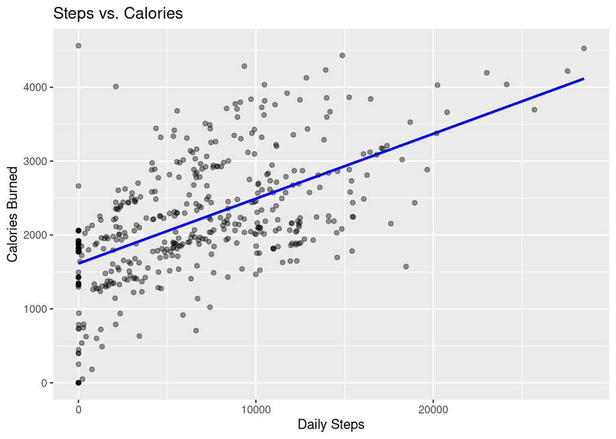

```r
# Visualizations
ggplot(daily, aes(total_steps, calories)) +
  geom_point(alpha = 0.4) +
  geom_smooth(method = "lm", se = FALSE, color="blue") +
  labs(title = "Steps vs. Calories", x = "Daily Steps", y = "Calories Burned")
```

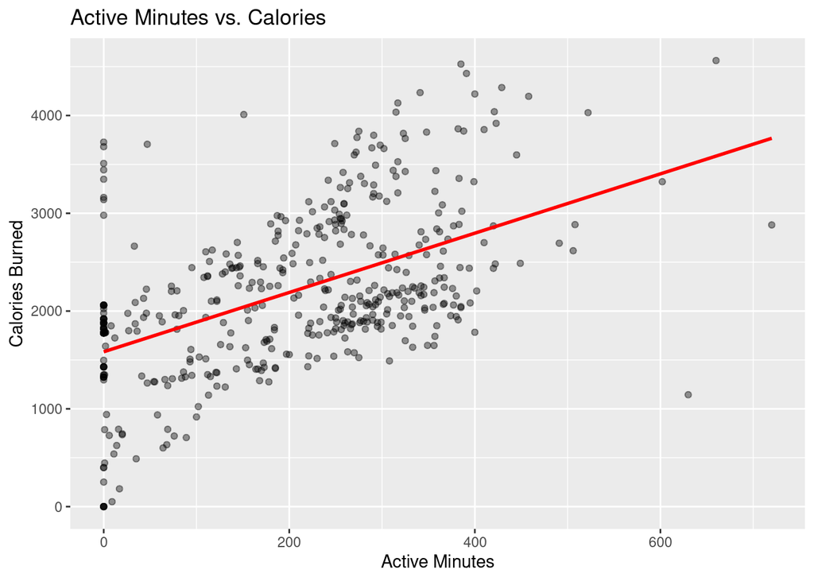

```r
ggplot(daily, aes(active_minutes, calories)) +
  geom_point(alpha = 0.4) +
  geom_smooth(method = "lm", se = FALSE, color="red") +
  labs(title = "Active Minutes vs. Calories", x = "Active Minutes", y = "Calories Burned")
```

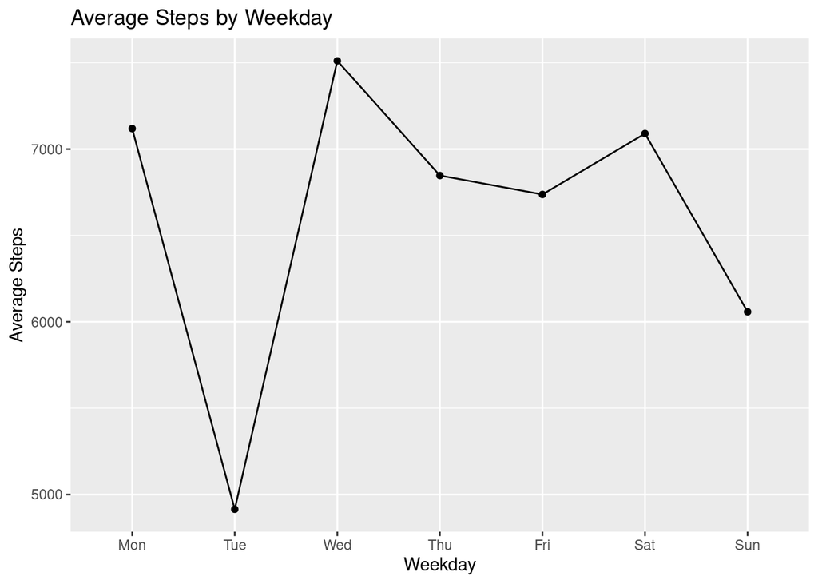

```r
daily %>%
  group_by(weekday) %>%
  summarise(mean_steps = mean(total_steps, na.rm = TRUE)) %>%
  ggplot(aes(weekday, mean_steps, group = 1)) +
  geom_line() + geom_point() +
  labs(title = "Average Steps by Weekday", x = "Weekday", y = "Average Steps")
```

[figure not shown]

```r
daily %>%
  group_by(weekpart) %>%
  summarise(mean_sleep = mean(total_minutes_asleep, na.rm = TRUE)) %>%
  ggplot(aes(weekpart, mean_sleep, fill = weekpart)) +
  geom_col() +
  labs(title = "Average Sleep: Weekday vs Weekend", x = "", y = "Minutes Asleep") +
  theme(legend.position = "none")
```

# 5 Share

**Steps vs. Calories**  
- Scatter plot shows positive relationship between steps and calories burned → can guide Bellabeat marketing to promote activity tracking

**General takeaway**  
- Predictable activity patterns can inform personalized notifications, challenges, or features to increase engagement with the Time

# 6 Act

**Recommendations**  
- Encourage daily activity: personalized reminders or weekend-specific challenges to increase engagement with the Time  
- Promote calorie-tracking & insights: highlight steps-calories relationship to motivate app usage  
- Leverage weekday patterns for campaigns: rewards or badges for hitting step targets to strengthen engagement

**Next steps**  
- Collect detailed sleep stages (light, deep, REM)  
- Track heart rate & stress metrics  
- Collect app usage logs (frequency, feature engagement)

**Experiments / A/B tests**  
- Test marketing messages emphasizing steps vs calories → measure engagement  
- Introduce weekend reminders → evaluate step count changes  
- Launch sleep challenge → track retention and participation

# 7 Appendix